# complete regression tutorial

[Home](https://annepu-ram.github.io/)

## Ram Annepu

### Multiple linear regression, assumptions and regularization

[figure not shown]

### Ordinary linear regression and its assumptions, weighted linear regression, Lasso regression, Ridge regression and Elastic Net Regression

After so many articles about regression on Medium.com, I think its best to abridge the definition and explanation of regression to avoid repetition. Regression is a line equation, when one predictor is used to predict the dependent variable. For two predictor variable, it is plane or a curved surface (when interaction terms are included).

Similarly, the concept can be expanded to dataset of mutiple dimensions.

###### All machine learning algorithms involve minimizing or maximizing a function or equation, called objective function. In other words, every machine learning problem or algorithm is an optimisation problem with a objective function and constraints.

###### In regression, the objective function is mean squared error and in deep learning, we use log loss function.

regression equation:

###### y=bx+b0

Here, y is predicted variable, b is coefficient and b0 is intercept (constant)

###### sum of mean squared error is given by

###### E=1/N Σ (Y - y)<sup>2</sup> Here Y is actual value

expanding the term by substituting the regression equation we get

###### E=1/N Σ (Y - bx+b0)<sup>2</sup>

###### Now to find the b0 and b at which the Error is minimum, we differentiate with respect to b and b0 and equate it to zero. ()

we get a regression line with slope b that passes through a point (mean of x, mean of Y).

But what exactly is b, b = cov(x,Y)/var(x)

Compare that with correlation coefficient corr(x,Y)=cov(x,Y)/(std(x)*std(y))

###### Hence b is similar to the correlation between x and Y. this can be reworded as, slope of the line is nothing but the correlation between the independent and dependent variable. sounds logical, isn't it.

The same definition and derivation can be extended to multiple linear regression.

### Assumptions of the Linear regression:

(L.I.N.E)

**Linearity:** Non linear data should be modeled with polynomial regression. Additionally, linear regression is highly susceptible to outliers.

**Independent (No Multicollinearity):** Multi-collinearity is the correlation between independent variables. methods to find and avoid this problems are detailed below.

**Normally distributed Independent variables:** Independent variables should be normally distributed, and if they are not, taking log transformation or feature engineering would help.

**Equal variance (Homoscedasticity):** Heteroscedarcity can be dealt by taking log transformation of features or by using weighted least square method.

#### Assumptions for residuals:

**No auto correlation among the residuals**

### Why use shrinkage/regularization factors?

Before we answer that question, we need to discuss about the lengendary bias vs variance trade-off phenomenon in data science. Different people have different definitions for this topic. I'll try to explain it in two lines. Bias is the difference between the expected (or average) prediction of multiple models created on different samples of the same population and the correct value (Truth) which we are trying to predict. Bias error decreases with increase in complexity of the model. And, variance error arises from sensitivity to small fluctuations in the training set. High variance can cause an algorithm to model the random noise in the training data, rather than the intended outputs. Total error is the sum of these two errors along with irreducible error. As more and more features are added to model, the bias decreases and model variance increases. Finally, it all comes down to complexity vs variance of the model. Decreasing complexity increases bias error but decreases model variance. According to Gauss Markov theorem, OLS has lowest variance or mean squared error among unbiased models (), given that (E(bi)=Bi). Therefore regularization is used to introduce bias and decrease model variance in regression.

L2 - Ridge A penalty term multiplied with squared coefficient is used to reduce or shrink the coefficients of regression, thus, introducing bias into the model. ridge is good for grouped selection.

L1 - Lasso A penalty term multiplied with absolute value of coefficients is used to reduce or shrink the coefficients of regression, thus, introducing bias into the model. Lasso also helps in feature selection. **Regularization helps in reducing the variance of the model and improves the prediction accuracy of the model.**

#### As suggested by Richard Berk In the book "Regression analysis: a constructive critique", simple linear regression works as descriptive tool, whereas regularized regression techniques can be used as predictive tool for more accurate prediction.

```python
%matplotlib inline
import matplotlib.pyplot as plt
import seaborn as sns; sns.set()
import numpy as np
import pandas as pd
import sklearn
import warnings
import os
warnings.filterwarnings('ignore')
%config IPCompleter.greedy=True
pd.set_option('display.max_rows', 50)
pd.set_option('display.max_columns', 50)
```

```python
os.getcwd()
```

```
'c:\\users\\annep\\documents\\notebooks'
```

```python
df_raw = pd.read_csv('SwissRailways.csv')
df_raw.head(10)
```

|  | id | YEAR | NI | STOPS | NETWORK | LABOREXP | STAFF | ELECEXP | KWH | TOTCOST | NARROW_T | RACK | TUNNEL | T | Q1 | Q2 | Q3 | CT | PL | PE | PK | VIRAGE | LABOR | ELEC | CAPITAL | LNCT | LNQ1 | LNQ2 | LNQ3 | … |
| --- | --- | --- | --- | --- | --- | --- | --- | --- | --- | --- | --- | --- | --- | --- | --- | --- | --- | --- | --- | --- | --- | --- | --- | --- | --- | --- | --- | --- | --- | --- |
| 0 | 1 | 90 | 7 | 10 | 13107 | 1061 | 16.0 | 163 | 1631 | 2536 | 0 | 0 | 0 | 5 | 159000 | 2401000 | 179385 | 3255.456 | 85125.16 | 0.128291 | 3709.715 | 0 | 41.83754 | 6.427445 | 51.73502 | 10.141540 | 11.97666 | 14.69140 | 12.09729 | … |
| 1 | 1 | 91 | 7 | 10 | 13107 | 1148 | 17.0 | 170 | 1428 | 2634 | 0 | 0 | 0 | 6 | 161000 | 2578000 | 196815 | 3162.065 | 81067.72 | 0.142914 | 3479.806 | 0 | 43.58390 | 6.454062 | 49.96203 | 10.004490 | 11.98916 | 14.76252 | 12.19002 | … |
| 2 | 1 | 92 | 7 | 10 | 7351 | 1145 | 17.0 | 196 | 2000 | 2846 | 0 | 0 | 0 | 7 | 158000 | 2573000 | 209298 | 3190.583 | 75507.78 | 0.109865 | 3716.343 | 0 | 40.23190 | 6.886859 | 52.88124 | 10.276460 | 11.97035 | 14.76058 | 12.25151 | … |
| 3 | 1 | 93 | 7 | 10 | 13107 | 1148 | 17.0 | 190 | 1305 | 2763 | 0 | 0 | 0 | 8 | 156000 | 2512000 | 121183 | 2964.592 | 72456.45 | 0.156217 | 3367.775 | 0 | 41.54904 | 6.876584 | 51.57438 | 9.851007 | 11.95761 | 14.73659 | 11.70506 | … |
| 4 | 1 | 94 | 7 | 10 | 13107 | 1138 | 16.0 | 203 | 1236 | 2874 | 0 | 0 | 0 | 9 | 149000 | 2431000 | 124408 | 2978.239 | 73704.66 | 0.170196 | 3499.121 | 0 | 39.59638 | 7.063326 | 53.34029 | 9.769890 | 11.91170 | 14.70381 | 11.73132 | … |
| 5 | 1 | 95 | 7 | 10 | 13107 | 1038 | 15.0 | 199 | 1226 | 2620 | 0 | 0 | 0 | 10 | 145000 | 2322000 | 56566 | 2689.938 | 71047.23 | 0.166649 | 3127.573 | 0 | 39.61832 | 7.595420 | 52.78626 | 9.689137 | 11.88449 | 14.65794 | 10.94316 | … |
| 6 | 1 | 96 | 7 | 10 | 13107 | 1018 | 15.0 | 160 | 1163 | 2899 | 0 | 0 | 0 | 11 | 144000 | 2168000 | 115340 | 2922.379 | 68413.98 | 0.138685 | 3821.320 | 0 | 35.11556 | 5.519145 | 59.36530 | 9.955706 | 11.87757 | 14.58932 | 11.65564 | … |
| 7 | 2 | 85 | 13 | 15 | 27024 | 2240 | 41.0 | 82 | 861 | 4006 | 1 | 0 | 0 | 0 | 245000 | 5291000 | 35196 | 5961.310 | 81300.81 | 0.141723 | 2303.265 | 1 | 55.91613 | 2.046930 | 42.03695 | 10.646920 | 12.40901 | 15.48152 | 10.46869 | … |
| 8 | 2 | 86 | 13 | 15 | 27024 | 2424 | 42.0 | 152 | 1597 | 4575 | 1 | 0 | 0 | 1 | 301000 | 6379000 | 37433 | 6480.170 | 81748.28 | 0.134814 | 2980.468 | 1 | 52.98361 | 3.322404 | 43.69399 | 10.780360 | 12.61487 | 15.66852 | 10.53031 | … |
| 9 | 2 | 87 | 13 | 15 | 27024 | 2558 | 46.0 | 180 | 1899 | 4875 | 1 | 0 | 0 | 2 | 336000 | 7522000 | 27382 | 6827.731 | 77883.33 | 0.132754 | 3150.523 | 1 | 52.47179 | 3.692308 | 43.83590 | 10.848000 | 12.72487 | 15.83334 | 10.21764 | … |

**Description of attributes**  
Swiss Railways, N = 49, T(i) = 3 to 13  
Variables in the file are  
ID = Company ID from 1 to 50 (49 companies, 604 obs) ID = 21 zero count.  
RAILROAD = Company ID reduced to remove gap at ID=21, values 1 to 49.  
YEAR = Year (1985 to 1997).  
NI = Number of year observations for firm, repeated in each observation.  
STOPS = Number of stations on the network.  
NETWORK = Length of railway network (m).  
LABOREXP = Labor expenses in 1000 CHF.  
STAFF = Number of employees.  
ELECEXP = Electricity expenses in 1000 CHF.  
KWH = Total consumed electricity (in 1000 kWh).  
TOTCOST = Total cost (in 1000 CHF).  
NARROW_T = Dummy for the networks with narrow track (1 m wide).  
RACK = Dummy for the networks with RACK RAIL (cremaillere) in at least some part;  
(used to maintain a slow movement of the train on high slopes).  
TUNNEL = Dummy for networks that have tunnels with an average length of more than 300 meters.  
VIRAGE = Dummy for the networks whose minimum radius of curvature is 100 meters or less.  
CT = Total costs adjusted for inflation (1000 CHF).  
Q1 = Total output in train kilometers.  
Q2 = Total passenger output in passenger kilometers.  
Q3 = Total goods output in ton kilometers.  
PL = Labor price adjusted for inflation (in CHF per person per year).  
PK = Capital price using the total number of seats as a proxy for capital stock (CHF per seat).  
PE = Price of electricity (CHF per kWh).  
LABOR = Quantity of labor.  
ELEC = Quantity of energy.  
CAPITAL = Quantity of Capital Capital costs = TOTCOST- (LABOREXP + ELECEXP)  
Inflation adjustment is done with respect to 1997 prices.  
Logs of costs and prices (lnCT, lnPK, lnPL) are normalized by PE.  
LNCT, LNPK, LNPL, LNQ1, LNQ2, LNQ3, LNSTOP, LNCAP, LNNET = logs of variables

lets make the dataset simpler by removing Logs of costs and prices (lnCT, lnPK, lnPL) that are normalized by PE. Also, since labor expenses and electricity expenses are directly related to total costs, the prediction variable, we remove these features too.

```python
df_raw.columns.values
```

```
array(['id', 'YEAR', 'NI', 'STOPS', 'NETWORK', 'LABOREXP', 'STAFF',
       'ELECEXP', 'KWH', 'TOTCOST', 'NARROW_T', 'RACK', 'TUNNEL', 'T',
       'Q1', 'Q2', 'Q3', 'CT', 'PL', 'PE', 'PK', 'VIRAGE', 'LABOR', 'ELEC',
       'CAPITAL', 'LNCT', 'LNQ1', 'LNQ2', 'LNQ3', 'LNNET', 'LNPL', 'LNPE',
       'LNPK', 'LNSTOP', 'LNCAP', 'RAILROAD '], dtype=object)
```

```python
df=df_raw[['STOPS', 'NETWORK', 'STAFF',
       'KWH', 'TOTCOST', 'NARROW_T', 'RACK', 'TUNNEL',
       'Q1', 'Q2', 'Q3', 'VIRAGE', 'LABOR', 'ELEC',
       'CAPITAL', 'LNQ1', 'LNQ2', 'LNQ3', 'LNNET', 'LNPE',
        'LNSTOP', 'LNCAP']]
```

```python
print(df.columns.values)
df.head(20)
```

```
['STOPS' 'NETWORK' 'STAFF' 'KWH' 'TOTCOST' 'NARROW_T' 'RACK' 'TUNNEL' 'Q1'
 'Q2' 'Q3' 'VIRAGE' 'LABOR' 'ELEC' 'CAPITAL' 'LNQ1' 'LNQ2' 'LNQ3' 'LNNET'
 'LNPE' 'LNSTOP' 'LNCAP']
```

|  | STOPS | NETWORK | STAFF | KWH | TOTCOST | NARROW_T | RACK | TUNNEL | Q1 | Q2 | Q3 | VIRAGE | LABOR | ELEC | CAPITAL | LNQ1 | LNQ2 | LNQ3 | LNNET | LNPE | LNSTOP | LNCAP |
| --- | --- | --- | --- | --- | --- | --- | --- | --- | --- | --- | --- | --- | --- | --- | --- | --- | --- | --- | --- | --- | --- | --- |
| 0 | 10 | 13107 | 16.0 | 1631 | 2536 | 0 | 0 | 0 | 159000 | 2401000 | 179385 | 0 | 41.83754 | 6.427445 | 51.73502 | 11.97666 | 14.69140 | 12.097290 | 2.573147 | -2.053454 | 2.302585 | 2.650892 |
| 1 | 10 | 13107 | 17.0 | 1428 | 2634 | 0 | 0 | 0 | 161000 | 2578000 | 196815 | 0 | 43.58390 | 6.454062 | 49.96203 | 11.98916 | 14.76252 | 12.190020 | 2.573147 | -1.945510 | 2.302585 | 2.650892 |
| 2 | 10 | 7351 | 17.0 | 2000 | 2846 | 0 | 0 | 0 | 158000 | 2573000 | 209298 | 0 | 40.23190 | 6.886859 | 52.88124 | 11.97035 | 14.76058 | 12.251510 | 1.994836 | -2.208499 | 2.302585 | 2.650892 |
| 3 | 10 | 13107 | 17.0 | 1305 | 2763 | 0 | 0 | 0 | 156000 | 2512000 | 121183 | 0 | 41.54904 | 6.876584 | 51.57438 | 11.95761 | 14.73659 | 11.705060 | 2.573147 | -1.856512 | 2.302585 | 2.650892 |
| 4 | 10 | 13107 | 16.0 | 1236 | 2874 | 0 | 0 | 0 | 149000 | 2431000 | 124408 | 0 | 39.59638 | 7.063326 | 53.34029 | 11.91170 | 14.70381 | 11.731320 | 2.573147 | -1.770802 | 2.302585 | 2.650892 |
| 5 | 10 | 13107 | 15.0 | 1226 | 2620 | 0 | 0 | 0 | 145000 | 2322000 | 56566 | 0 | 39.61832 | 7.595420 | 52.78626 | 11.88449 | 14.65794 | 10.943160 | 2.573147 | -1.791863 | 2.302585 | 2.650892 |
| 6 | 10 | 13107 | 15.0 | 1163 | 2899 | 0 | 0 | 0 | 144000 | 2168000 | 115340 | 0 | 35.11556 | 5.519145 | 59.36530 | 11.87757 | 14.58932 | 11.655640 | 2.573147 | -1.975552 | 2.302585 | 2.650892 |
| 7 | 15 | 27024 | 41.0 | 861 | 4006 | 1 | 0 | 0 | 245000 | 5291000 | 35196 | 1 | 55.91613 | 2.046930 | 42.03695 | 12.40901 | 15.48152 | 10.468690 | 3.296725 | -1.953878 | 2.708050 | 3.251079 |
| 8 | 15 | 27024 | 42.0 | 1597 | 4575 | 1 | 0 | 0 | 301000 | 6379000 | 37433 | 1 | 52.98361 | 3.322404 | 43.69399 | 12.61487 | 15.66852 | 10.530310 | 3.296725 | -2.003862 | 2.708050 | 3.251079 |
| 9 | 15 | 27024 | 46.0 | 1899 | 4875 | 1 | 0 | 0 | 336000 | 7522000 | 27382 | 1 | 52.47179 | 3.692308 | 43.83590 | 12.72487 | 15.83334 | 10.217640 | 3.296725 | -2.019253 | 2.708050 | 3.251079 |
| 10 | 16 | 27024 | 45.0 | 1913 | 5132 | 1 | 0 | 0 | 341000 | 7575000 | 27273 | 1 | 52.02650 | 3.702260 | 44.27124 | 12.73964 | 15.84036 | 10.213650 | 3.296725 | -1.991950 | 2.772589 | 3.251079 |
| 11 | 16 | 27024 | 47.0 | 1883 | 5450 | 1 | 0 | 0 | 332000 | 7868000 | 28009 | 1 | 53.70642 | 3.449541 | 42.84404 | 12.71289 | 15.87831 | 10.240280 | 3.296725 | -2.012489 | 2.772589 | 3.251079 |
| 12 | 16 | 27024 | 47.0 | 2105 | 5872 | 1 | 0 | 0 | 373000 | 8438000 | 17733 | 1 | 56.72684 | 3.593324 | 39.67984 | 12.82933 | 15.94826 | 9.783182 | 3.296725 | -2.050468 | 2.772589 | 3.251079 |
| 13 | 16 | 27024 | 49.0 | 2209 | 6820 | 1 | 0 | 0 | 411000 | 9064000 | 13610 | 1 | 56.14370 | 3.475073 | 40.38123 | 12.92635 | 16.01982 | 9.518560 | 3.296725 | -2.049513 | 2.772589 | 3.251079 |
| 14 | 17 | 27024 | 51.0 | 2357 | 7229 | 1 | 0 | 0 | 433000 | 9130000 | 11849 | 1 | 57.98866 | 3.513626 | 38.49772 | 12.97849 | 16.02708 | 9.379999 | 3.296725 | -2.113522 | 2.833213 | 3.251079 |
| 15 | 17 | 27024 | 50.0 | 2279 | 7115 | 1 | 0 | 0 | 419000 | 10600000 | 12556 | 1 | 60.42165 | 3.682361 | 35.89599 | 12.94563 | 16.17249 | 9.437954 | 3.296725 | -2.092725 | 2.833213 | 3.251079 |
| 16 | 17 | 27024 | 49.0 | 2337 | 6911 | 1 | 0 | 0 | 431000 | 10100000 | 12090 | 1 | 61.06208 | 4.123860 | 34.81406 | 12.97386 | 16.12775 | 9.400134 | 3.296725 | -2.068507 | 2.833213 | 3.251079 |
| 17 | 17 | 27024 | 48.0 | 2086 | 7433 | 1 | 0 | 0 | 428000 | 9875000 | 9598 | 1 | 54.83654 | 3.430647 | 41.73281 | 12.96688 | 16.10552 | 9.169310 | 3.296725 | -2.075396 | 2.833213 | 3.251079 |
| 18 | 17 | 27024 | 46.0 | 2347 | 7284 | 1 | 0 | 0 | 428000 | 9817000 | 9875 | 1 | 58.49808 | 4.146074 | 37.35585 | 12.96688 | 16.09963 | 9.197762 | 3.296725 | -2.042434 | 2.833213 | 3.251079 |
| 19 | 17 | 27024 | 49.0 | 2343 | 7157 | 1 | 0 | 0 | 429000 | 10100000 | 8622 | 1 | 59.95529 | 4.191700 | 35.85301 | 12.96921 | 16.12914 | 9.062073 | 3.296725 | -2.055405 | 2.833213 | 3.251079 |

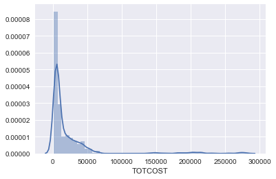

```python
#lets study variables
sns.distplot(df.TOTCOST )
```

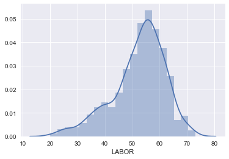

```python
sns.distplot(df.LABOR)
```

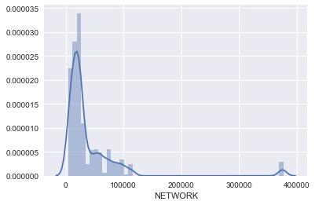

```python
sns.distplot(df.NETWORK)
```

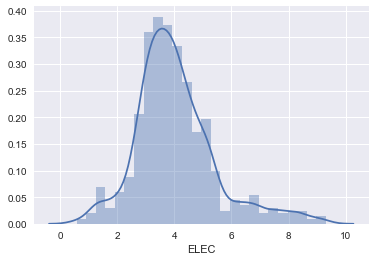

```python
sns.distplot(df.ELEC)
```

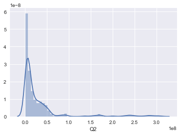

```python
sns.distplot(df.Q2)
```

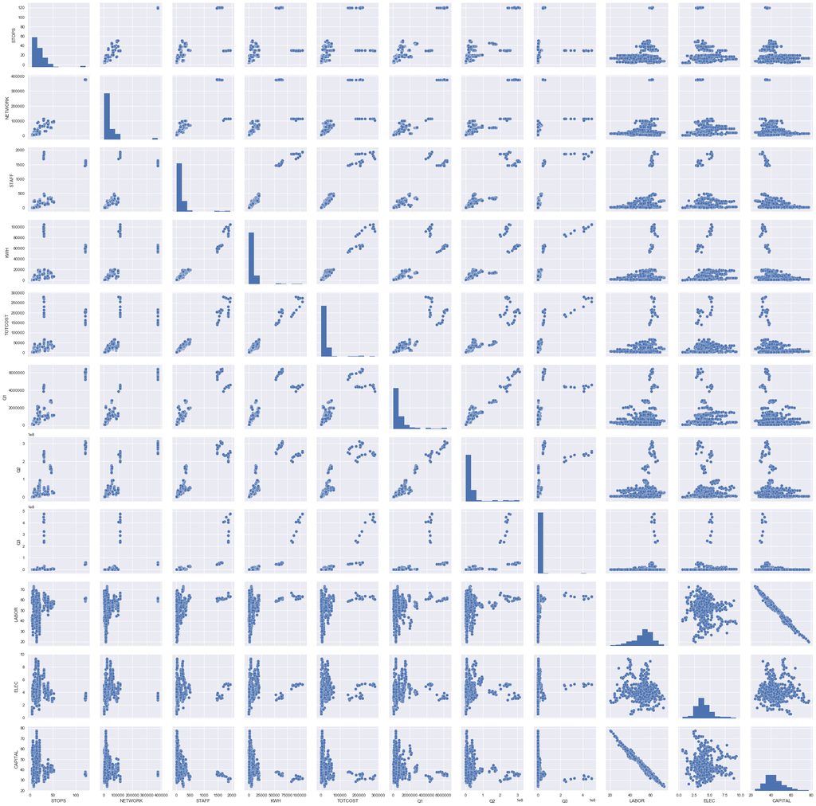

```python
##### pair plots for correlation analysis
#sns.color_palette("Set1")
sns.pairplot(df[['STOPS', 'NETWORK', 'STAFF',
       'KWH', 'TOTCOST',
       'Q1', 'Q2', 'Q3', 'LABOR', 'ELEC',
       'CAPITAL']])
```

```python
df.isnull().sum()
```

```
STOPS       0
NETWORK     0
STAFF       0
KWH         0
TOTCOST     0
NARROW_T    0
RACK        0
TUNNEL      0
Q1          0
Q2          0
Q3          0
VIRAGE      0
LABOR       0
ELEC        0
CAPITAL     0
LNQ1        0
LNQ2        0
LNQ3        0
LNNET       0
LNPE        0
LNSTOP      0
LNCAP       0
dtype: int64
```

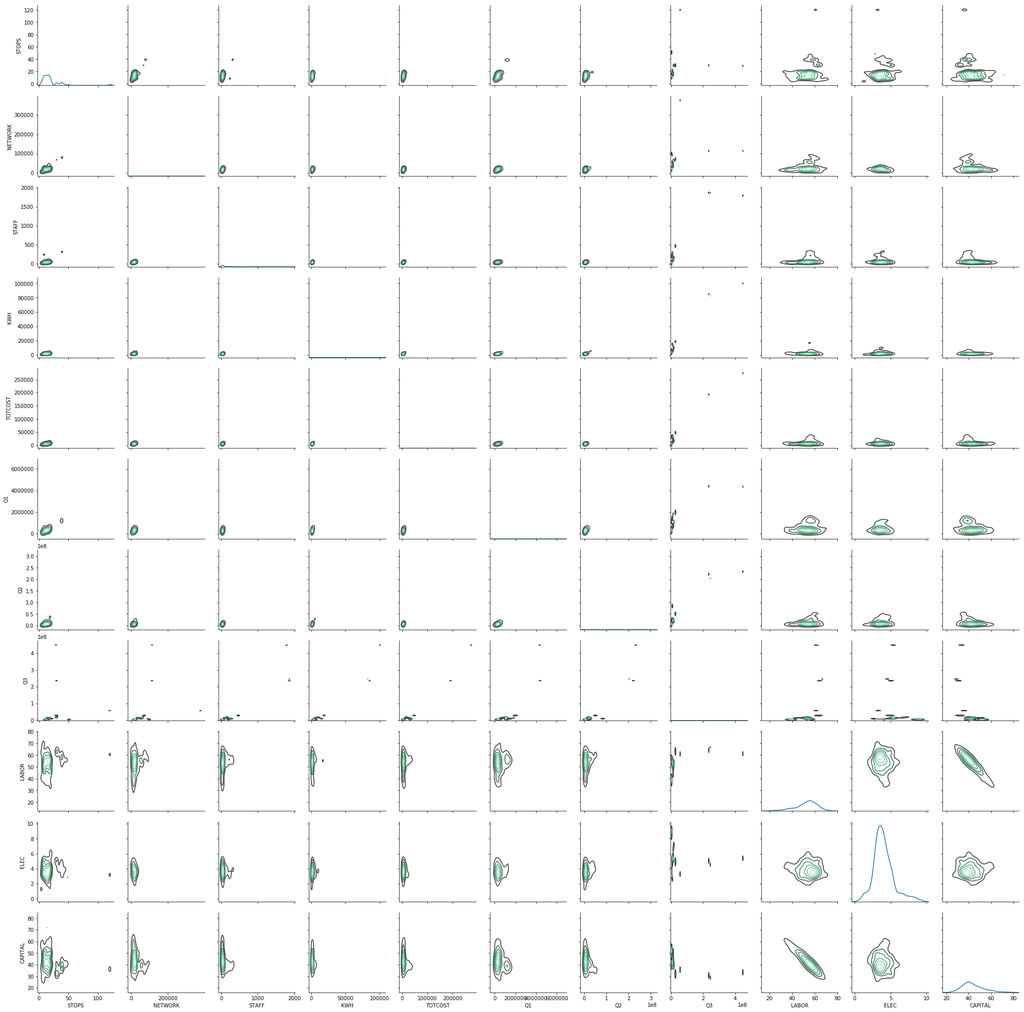

```python
#sns.light_palette("navy", reverse=True)
#cmap = sns.cubehelix_palette(light=1, as_cmap=True)
sns.reset_orig()
g = sns.PairGrid(df[['STOPS', 'NETWORK', 'STAFF',
       'KWH', 'TOTCOST',
       'Q1', 'Q2', 'Q3', 'LABOR', 'ELEC',
       'CAPITAL']])
g.map_diag(sns.kdeplot)
g.map_offdiag(sns.kdeplot, n_levels=6);
```

**Since our main intension behind this notebook is to try regression with different cost functions and variable selection methods, lets begin with the modeling without any further ado. As discussed in the clustering notebook, the data should be normalized before modelling**

```python
#subsetting the attributes for modelling.
df.temp=df.loc[:, df.columns != 'TOTCOST']
df.temp.head()
```

|  | STOPS | NETWORK | STAFF | KWH | NARROW_T | RACK | TUNNEL | Q1 | Q2 | Q3 | VIRAGE | LABOR | ELEC | CAPITAL | LNQ1 | LNQ2 | LNQ3 | LNNET | LNPE | LNSTOP | LNCAP |
| --- | --- | --- | --- | --- | --- | --- | --- | --- | --- | --- | --- | --- | --- | --- | --- | --- | --- | --- | --- | --- | --- |
| 0 | 10 | 13107 | 16.0 | 1631 | 0 | 0 | 0 | 159000 | 2401000 | 179385 | 0 | 41.83754 | 6.427445 | 51.73502 | 11.97666 | 14.69140 | 12.09729 | 2.573147 | -2.053454 | 2.302585 | 2.650892 |
| 1 | 10 | 13107 | 17.0 | 1428 | 0 | 0 | 0 | 161000 | 2578000 | 196815 | 0 | 43.58390 | 6.454062 | 49.96203 | 11.98916 | 14.76252 | 12.19002 | 2.573147 | -1.945510 | 2.302585 | 2.650892 |
| 2 | 10 | 7351 | 17.0 | 2000 | 0 | 0 | 0 | 158000 | 2573000 | 209298 | 0 | 40.23190 | 6.886859 | 52.88124 | 11.97035 | 14.76058 | 12.25151 | 1.994836 | -2.208499 | 2.302585 | 2.650892 |
| 3 | 10 | 13107 | 17.0 | 1305 | 0 | 0 | 0 | 156000 | 2512000 | 121183 | 0 | 41.54904 | 6.876584 | 51.57438 | 11.95761 | 14.73659 | 11.70506 | 2.573147 | -1.856512 | 2.302585 | 2.650892 |
| 4 | 10 | 13107 | 16.0 | 1236 | 0 | 0 | 0 | 149000 | 2431000 | 124408 | 0 | 39.59638 | 7.063326 | 53.34029 | 11.91170 | 14.70381 | 11.73132 | 2.573147 | -1.770802 | 2.302585 | 2.650892 |

```python
from sklearn import preprocessing
df.scaled = preprocessing.scale(df.temp)
```

```python
df.scaled
```

```
array([[-0.5629073 , -0.46297081, -0.46206069, ..., -1.26772948,
        -0.72052812, -1.48360239],
       [-0.5629073 , -0.46297081, -0.45905378, ..., -0.56130556,
        -0.72052812, -1.48360239],
       [-0.5629073 , -0.56499434, -0.45905378, ..., -2.28239909,
        -0.72052812, -1.48360239],
       ...,
       [ 5.47735469,  5.9868801 ,  4.10843935, ..., -2.08378444,
         3.10123292, -0.12927144],
       [ 5.47735469,  5.9868801 ,  3.95208014, ..., -1.32083693,
         3.10123292, -0.12927144],
       [ 5.36852114,  5.9868801 ,  3.84082454, ..., -2.62852351,
         3.07568304, -0.12927144]])
```

```python
from sklearn.linear_model import LinearRegression
from sklearn.metrics import mean_squared_error, r2_score
import statsmodels.api as sm
from scipy import stats

X=df.loc[:, df.columns != 'TOTCOST']
y=df[['TOTCOST']]
X2 = sm.add_constant(X) #beta0 or intercept to the model
est = sm.OLS(y, X2)
model = est.fit()
print(model.summary())
```

```
                            OLS Regression Results
==============================================================================
Dep. Variable:                TOTCOST   R-squared:                       0.984
Model:                            OLS   Adj. R-squared:                  0.983
Method:                 Least Squares   F-statistic:                     1750.
Date:                Wed, 03 Apr 2019   Prob (F-statistic):               0.00
Time:                        21:54:39   Log-Likelihood:                -6047.8
No. Observations:                 604   AIC:                         1.214e+04
Df Residuals:                     583   BIC:                         1.223e+04
Df Model:                          20
Covariance Type:            nonrobust
==============================================================================
                 coef    std err          t      P>|t|      [0.025      0.975]
------------------------------------------------------------------------------
const        -21.7121      4.422     -4.910      0.000     -30.398     -13.026
STOPS        269.8442    137.355      1.965      0.050       0.072     539.616
NETWORK        0.1123      0.036      3.091      0.002       0.041       0.184
STAFF        -16.6760      7.224     -2.308      0.021     -30.865      -2.487
KWH            1.8598      0.193      9.622      0.000       1.480       2.239
NARROW_T   -3087.5008   1424.067     -2.168      0.031   -5884.427    -290.575
RACK        2965.2821    724.182      4.095      0.000    1542.958    4387.606
TUNNEL     -2297.8698    953.082     -2.411      0.016   -4169.763    -425.977
Q1            -0.0027      0.002     -1.201      0.230      -0.007       0.002
Q2             0.0001   3.09e-05      4.405      0.000    7.55e-05       0.000
Q3             0.0002   1.98e-05      7.856      0.000       0.000       0.000
VIRAGE      3377.3691   1424.574      2.371      0.018     579.446    6175.292
LABOR       -134.3962    134.503     -0.999      0.318    -398.566     129.773
ELEC       -1938.3287    272.185     -7.121      0.000   -2472.911   -1403.746
CAPITAL      -98.4774    130.140     -0.757      0.450    -354.077     157.123
LNQ1        -497.7727   2060.705     -0.242      0.809   -4545.082    3549.536
LNQ2        3478.3767    998.965      3.482      0.001    1516.369    5440.385
LNQ3        -128.7748    178.577     -0.721      0.471    -479.507     221.957
LNNET       -222.3410   1212.392     -0.183      0.855   -2603.528    2158.846
LNPE        4219.4687   1764.663      2.391      0.017     753.598    7685.339
LNSTOP     -5543.6414   2412.607     -2.298      0.022   -1.03e+04    -805.182
LNCAP      -2707.2628   1172.768     -2.308      0.021   -5010.627    -403.898
==============================================================================
Omnibus:                      142.699   Durbin-Watson:                   0.412
Prob(Omnibus):                  0.000   Jarque-Bera (JB):             2423.922
Skew:                           0.542   Prob(JB):                         0.00
Kurtosis:                      12.754   Cond. No.                     1.81e+15
==============================================================================

Warnings:
[1] Standard Errors assume that the covariance matrix of the errors is correctly specified.
[2] The smallest eigenvalue is 1.02e-12. This might indicate that there are
strong multicollinearity problems or that the design matrix is singular.
```

Also according to the fundamental assumptions of regression, every predictor variable should be independent of other variables. The correlation among the features can cause multi collinearity. why is this multi-collienarity such big issue? glad you asked. The basic definition of regression cofficients is that the increase of response variable when the predictor variable is increased by a unit while keeping all other variables constant. Yes, keeping all other variables constant is the important part here. When the features are correlated, we cannot keep other variables constant. Hence, it breakdowns the entire regression equation.

y=b1(X)+b2(X)+b3(X)+b0

There are several methods to find correlated features; Correlation plots and variance inflation methods are few of them.

But, feature selection can also be done by other methods such as  
forward selection: here the model starts from null model to full model by selecting one feature at a time and by evaluating each models accuracy statistics (R2, AIC and BIC)  
Backward elimination: eliminates individual feature from full model until the best model is obtained.  
stepwise slection: In this method we do both the bove methods simultaneously by doing partial F-test</strong></i>

**comparing the variation inflation factor with correlation coefficients, we can identify features that are highly correlated and avoid multicollinearity problems**

```python
from statsmodels.stats.outliers_influence import variance_inflation_factor
for j in range(X.shape[1]):
    print (df.columns.values[j],variance_inflation_factor(X.values, j))
```

```
STOPS 127.440136513
NETWORK 84.0999520981
STAFF 115.460180091
KWH 181.246228083
TOTCOST 8.86797367744
NARROW_T 1.88639315417
RACK 2.78206760096
TUNNEL 116.668971283
Q1 57.9987118074
Q2 21.8546367338
Q3 8.2387287145
VIRAGE 1027.23285999
LABOR 27.1979168373
ELEC 673.606590656
CAPITAL 86.1323886389
LNQ1 35.7080413282
LNQ2 4.68194573423
LNQ3 24.0928637212
LNNET 1.45435136415
LNPE 49.5498154984
LNSTOP 2.96043864134
```

```python
#cols=[0,1,3,4]
df.corr()
```

|  | STOPS | NETWORK | STAFF | KWH | TOTCOST | NARROW_T | RACK | TUNNEL | Q1 | Q2 | Q3 | VIRAGE | LABOR | ELEC | CAPITAL | LNQ1 | LNQ2 | LNQ3 | LNNET | LNPE | LNSTOP | LNCAP |
| --- | --- | --- | --- | --- | --- | --- | --- | --- | --- | --- | --- | --- | --- | --- | --- | --- | --- | --- | --- | --- | --- | --- |
| STOPS | 1.000000 | 0.937483 | 0.676245 | 0.587233 | 0.652653 | 0.221042 | -0.138500 | 0.402401 | 0.833750 | 0.765818 | 0.191431 | 0.190760 | 0.220767 | -0.024349 | -0.220353 | 0.716570 | 0.649731 | 0.483496 | 0.774594 | -0.222202 | 0.867703 | 0.011668 |
| NETWORK | 0.937483 | 1.000000 | 0.790394 | 0.708852 | 0.762797 | 0.075749 | -0.091713 | 0.419698 | 0.871335 | 0.818496 | 0.311179 | 0.044869 | 0.236263 | 0.017797 | -0.242405 | 0.669803 | 0.621301 | 0.554145 | 0.776215 | -0.212689 | 0.720221 | -0.077349 |
| STAFF | 0.676245 | 0.790394 | 1.000000 | 0.981292 | 0.981150 | -0.096577 | -0.085073 | 0.494285 | 0.917086 | 0.921017 | 0.783490 | -0.121627 | 0.298010 | 0.078934 | -0.314238 | 0.674856 | 0.661000 | 0.613199 | 0.656203 | -0.153619 | 0.550021 | -0.071705 |
| KWH | 0.587233 | 0.708852 | 0.981292 | 1.000000 | 0.981919 | -0.174182 | -0.108910 | 0.510177 | 0.883055 | 0.893069 | 0.855668 | -0.199182 | 0.247461 | 0.178892 | -0.277956 | 0.664089 | 0.650076 | 0.618470 | 0.619940 | -0.126006 | 0.506215 | -0.095261 |
| TOTCOST | 0.652653 | 0.762797 | 0.981150 | 0.981919 | 1.000000 | -0.106021 | -0.090182 | 0.512486 | 0.905470 | 0.918659 | 0.812322 | -0.124588 | 0.252610 | 0.095354 | -0.270637 | 0.679804 | 0.669411 | 0.611614 | 0.650564 | -0.145257 | 0.544439 | -0.068818 |
| NARROW_T | 0.221042 | 0.075749 | -0.096577 | -0.174182 | -0.106021 | 1.000000 | 0.274255 | -0.110358 | -0.023946 | -0.032331 | -0.218845 | 0.910120 | 0.072376 | -0.464770 | -0.003653 | 0.111019 | 0.108543 | -0.420119 | 0.129899 | -0.198490 | 0.314526 | 0.503465 |
| RACK | -0.138500 | -0.091713 | -0.085073 | -0.108910 | -0.090182 | 0.274255 | 1.000000 | -0.007995 | -0.175809 | -0.139335 | -0.103634 | 0.235738 | 0.205715 | -0.116043 | -0.191312 | -0.217385 | -0.121740 | -0.342599 | -0.087045 | -0.004416 | -0.158986 | 0.200514 |
| TUNNEL | 0.402401 | 0.419698 | 0.494285 | 0.510177 | 0.512486 | -0.110358 | -0.007995 | 1.000000 | 0.535252 | 0.617501 | 0.324352 | -0.044377 | -0.051990 | 0.275888 | 0.011328 | 0.480588 | 0.566684 | 0.352088 | 0.400839 | 0.042044 | 0.388774 | 0.125645 |
| Q1 | 0.833750 | 0.871335 | 0.917086 | 0.883055 | 0.905470 | -0.023946 | -0.175809 | 0.535252 | 1.000000 | 0.965545 | 0.566255 | -0.048813 | 0.229915 | 0.125315 | -0.252108 | 0.821516 | 0.779904 | 0.623884 | 0.743461 | -0.188072 | 0.714909 | -0.063535 |
| Q2 | 0.765818 | 0.818496 | 0.921017 | 0.893069 | 0.918659 | -0.032331 | -0.139335 | 0.617501 | 0.965545 | 1.000000 | 0.608059 | -0.048558 | 0.234328 | 0.094527 | -0.251962 | 0.744904 | 0.756053 | 0.582984 | 0.670537 | -0.175236 | 0.625587 | 0.041099 |
| Q3 | 0.191431 | 0.311179 | 0.783490 | 0.855668 | 0.812322 | -0.218845 | -0.103634 | 0.324352 | 0.566255 | 0.608059 | 1.000000 | -0.242653 | 0.176697 | 0.122147 | -0.197632 | 0.385020 | 0.374809 | 0.452011 | 0.322399 | -0.029540 | 0.214631 | -0.105037 |
| VIRAGE | 0.190760 | 0.044869 | -0.121627 | -0.199182 | -0.124588 | 0.910120 | 0.235738 | -0.044377 | -0.048813 | -0.048558 | -0.242653 | 1.000000 | -0.000686 | -0.501909 | 0.076059 | 0.088650 | 0.090084 | -0.399277 | 0.086584 | -0.196262 | 0.261437 | 0.512594 |
| LABOR | 0.220767 | 0.236263 | 0.298010 | 0.247461 | 0.252610 | 0.072376 | 0.205715 | -0.051990 | 0.229915 | 0.234328 | 0.176697 | -0.000686 | 1.000000 | -0.171082 | -0.988997 | 0.166294 | 0.212082 | 0.142532 | 0.243992 | -0.231094 | 0.192714 | 0.287272 |
| ELEC | -0.024349 | 0.017797 | 0.078934 | 0.178892 | 0.095354 | -0.464770 | -0.116043 | 0.275888 | 0.125315 | 0.094527 | 0.122147 | -0.501909 | -0.171082 | 1.000000 | 0.023443 | 0.238740 | 0.250492 | 0.294408 | 0.168856 | 0.246700 | 0.086106 | -0.248853 |
| CAPITAL | -0.220353 | -0.242405 | -0.314238 | -0.277956 | -0.270637 | -0.003653 | -0.191312 | 0.011328 | -0.252108 | -0.251962 | -0.197632 | 0.076059 | -0.988997 | 0.023443 | 1.000000 | -0.204583 | -0.252808 | -0.188831 | -0.272929 | 0.197445 | -0.208473 | -0.254125 |
| LNQ1 | 0.716570 | 0.669803 | 0.674856 | 0.664089 | 0.679804 | 0.111019 | -0.217385 | 0.480588 | 0.821516 | 0.744904 | 0.385020 | 0.088650 | 0.166294 | 0.238740 | -0.204583 | 1.000000 | 0.953608 | 0.642355 | 0.879468 | -0.098619 | 0.840233 | 0.005468 |
| LNQ2 | 0.649731 | 0.621301 | 0.661000 | 0.650076 | 0.669411 | 0.108543 | -0.121740 | 0.566684 | 0.779904 | 0.756053 | 0.374809 | 0.090084 | 0.212082 | 0.250492 | -0.252808 | 0.953608 | 1.000000 | 0.600872 | 0.825550 | -0.114533 | 0.761829 | 0.152731 |
| LNQ3 | 0.483496 | 0.554145 | 0.613199 | 0.618470 | 0.611614 | -0.420119 | -0.342599 | 0.352088 | 0.623884 | 0.582984 | 0.452011 | -0.399277 | 0.142532 | 0.294408 | -0.188831 | 0.642355 | 0.600872 | 1.000000 | 0.657063 | 0.109996 | 0.457153 | -0.287333 |
| LNNET | 0.774594 | 0.776215 | 0.656203 | 0.619940 | 0.650564 | 0.129899 | -0.087045 | 0.400839 | 0.743461 | 0.670537 | 0.322399 | 0.086584 | 0.243992 | 0.168856 | -0.272929 | 0.879468 | 0.825550 | 0.657063 | 1.000000 | -0.055171 | 0.851932 | -0.043606 |
| LNPE | -0.222202 | -0.212689 | -0.153619 | -0.126006 | -0.145257 | -0.198490 | -0.004416 | 0.042044 | -0.188072 | -0.175236 | -0.029540 | -0.196262 | -0.231094 | 0.246700 | 0.197445 | -0.098619 | -0.114533 | 0.109996 | -0.055171 | 1.000000 | -0.144047 | -0.110212 |
| LNSTOP | 0.867703 | 0.720221 | 0.550021 | 0.506215 | 0.544439 | 0.314526 | -0.158986 | 0.388774 | 0.714909 | 0.625587 | 0.214631 | 0.261437 | 0.192714 | 0.086106 | -0.208473 | 0.840233 | 0.761829 | 0.457153 | 0.851932 | -0.144047 | 1.000000 | 0.093964 |
| LNCAP | 0.011668 | -0.077349 | -0.071705 | -0.095261 | -0.068818 | 0.503465 | 0.200514 | 0.125645 | -0.063535 | 0.041099 | -0.105037 | 0.512594 | 0.287272 | -0.248853 | -0.254125 | 0.005468 | 0.152731 | -0.287333 | -0.043606 | -0.110212 | 0.093964 | 1.000000 |

```python
from sklearn.feature_selection import RFE
from sklearn.linear_model import LinearRegression
model = LinearRegression()
rfe = RFE(model,13)
fit = rfe.fit(X, y)
y_pred=fit.predict(X)
print("Num Features: %s" % (fit.n_features_))
print("Selected Features: %s" % (fit.support_))
print("Feature Ranking: %s" % (fit.ranking_))
```

[output not shown]

```python
print("Mean squared error: %.2f"
      % mean_squared_error(y, y_pred))
# Explained variance score: 1 is perfect prediction
print('Variance score: %.2f' % r2_score(y, y_pred))
```

```
Mean squared error: 490612376.54
Variance score: 0.72
```

**Feature selection didnt give a optimal set of features.**

**We see that recursive feature elimination doesn't always yield optimal feature set, especially not helpful in rejecting the features that cause multi-collinearity. For these reasons, we apply VIF and filter out the features that have VIF factor by coss-referencing with correlation matrix created. In this particular case, we find that 'VIRAGE', 'STOPS', 'ELEC' and 'KWH' have high VIF factor. Also, all the insignificant features should be removed to get parsimonious model**

```python
X.corr()
```

[output not shown]

```python
from sklearn.linear_model import LinearRegression
from sklearn.metrics import mean_squared_error, r2_score
import statsmodels.api as sm
from scipy import stats

X=df.loc[:, df.columns != 'TOTCOST']
y=df[['TOTCOST']]
X['LNKWH']=np.log(X.KWH)
X['LNLABOR']=np.log(X.LABOR)
X['LNSTAFF']=np.log(X.STAFF)
X2 = sm.add_constant(X[[ 'LNKWH','LNQ2','LNQ3','STOPS','LNSTAFF','LNNET','ELEC','TUNNEL']]) #beta0 or intercept to the model
est = sm.OLS(y, X2)
model = est.fit()
print(model.summary())
```

```
                            OLS Regression Results
==============================================================================
Dep. Variable:                TOTCOST   R-squared:                       0.728
Model:                            OLS   Adj. R-squared:                  0.724
Method:                 Least Squares   F-statistic:                     199.0
Date:                Wed, 03 Apr 2019   Prob (F-statistic):          1.09e-162
Time:                        22:39:33   Log-Likelihood:                -6896.3
No. Observations:                 604   AIC:                         1.381e+04
Df Residuals:                     595   BIC:                         1.385e+04
Df Model:                           8
Covariance Type:            nonrobust
==============================================================================
                 coef    std err          t      P>|t|      [0.025      0.975]
------------------------------------------------------------------------------
const        1.77e+04   2.16e+04      0.818      0.414   -2.48e+04    6.02e+04
LNKWH       3.897e+04   4529.019      8.605      0.000    3.01e+04    4.79e+04
LNQ2       -1.878e+04   2156.844     -8.709      0.000    -2.3e+04   -1.45e+04
LNQ3        3112.0238    478.238      6.507      0.000    2172.783    4051.264
STOPS        629.9722     82.994      7.591      0.000     466.975     792.969
LNSTAFF     8106.1383   3721.291      2.178      0.030     797.676    1.54e+04
LNNET      -1.764e+04   2522.807     -6.993      0.000   -2.26e+04   -1.27e+04
ELEC       -8891.6243   1252.454     -7.099      0.000   -1.14e+04   -6431.856
TUNNEL      1.969e+04   2936.610      6.705      0.000    1.39e+04    2.55e+04
==============================================================================
Omnibus:                      401.617   Durbin-Watson:                   0.235
Prob(Omnibus):                  0.000   Jarque-Bera (JB):             5954.250
Skew:                           2.739   Prob(JB):                         0.00
Kurtosis:                      17.373   Cond. No.                         823.
==============================================================================

Warnings:
[1] Standard Errors assume that the covariance matrix of the errors is correctly specified.
```

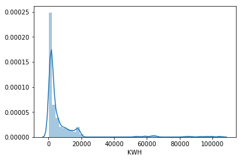

```python
sns.distplot(X.KWH)
```

```python
X.columns.values
```

[output not shown]

```python
regr = LinearRegression()

# Train the model using the training sets
regr.fit(X[[ 'LNKWH','LNQ2','LNQ3','STOPS','LNSTAFF','LNNET','ELEC','TUNNEL','KWH']].values, y.values)

# Make predictions using the testing set
y_pred = regr.predict(X[[ 'LNKWH','LNQ2','LNQ3','STOPS','LNSTAFF','LNNET','ELEC','TUNNEL','KWH']].values)
```

```python
from math import sqrt
from sklearn.metrics import mean_squared_error, r2_score
print("Mean squared error: %.2f"
      % mean_squared_error(y, y_pred))
print("Root mean squared error: %.2f"
      % sqrt(mean_squared_error(y, y_pred)))
# Explained variance score: 1 is perfect prediction
print('Variance score: %.2f' % r2_score(y, y_pred))
```

```
Mean squared error: 38106449.16
Root mean squared error: 6173.04
Variance score: 0.98
```

```python
residuals=(y-y_pred)
#residuals
```

[output not shown]

604 rows × 1 columns

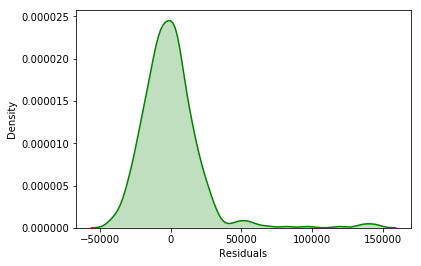

```python
ax=sns.kdeplot(residuals.TOTCOST,shade=True,color="g",legend=False)
ax.set(xlabel='Residuals', ylabel='Density')
plt.show()
```

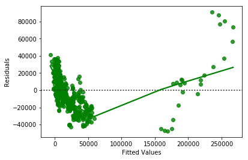

```python
ax=sns.residplot(y_pred.flatten(),residuals.TOTCOST.values, lowess=True, color="g")
ax.set(xlabel='Fitted Values', ylabel='Residuals')
plt.show()
```

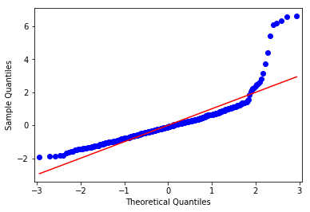

```python
from statsmodels.graphics.gofplots import qqplot
qqplot(preprocessing.scale(residuals.TOTCOST), line='s')
plt.show()
```

*Theres a high heteroscedarcity because of outliers. The only way to reduce this is to remove the outliers or model them seperately*

*The fitted values vs residuals plot clearly shows heteroskedasticity, which in other words means increase of variance of predicted values with increase in the values of predictors. Lets confirm our assumption with Breush-Pagan Test, the test thats done to find conditional heteroskedasticity*

```python
from statsmodels.compat import lzip

name = ['Lagrange multiplier statistic', 'p-value',
        'f-value', 'f p-value']
test=sm.stats.diagnostic.het_breuschpagan(residuals.TOTCOST.values ,X[[ 'LNKWH','LNQ2','LNQ3','STOPS','LNSTAFF','LNNET','ELEC','TUNNEL','KWH']].values)
lzip(name, test)
```

```
[('Lagrange multiplier statistic', 424.72777958369284),
 ('p-value', 9.5669769244734404e-87),
 ('f-value', 156.62898224179548),
 ('f p-value', 1.3537616000591543e-150)]
```

Null Hypothesis: Error terms are homoscedastic  
Alternative Hypothesis: Error terms are heteroscedastic.  
But since p value is almost 0 we can reject the null hypothesis. (we consider the null hypothesis when the p values is significantly greater than 0.05) Hherefore the residuals are heteroskedastic  
Hence it is essential to transform the data to remove heteroskedasticity.

```python
import math
trans_y=y.TOTCOST.apply(math.log)
```

```python
#X['FEED/COWS']=X["FEED"]/X["COWS"]
```

```python
from scipy import stats
import numpy as np
regr.fit(X[[ 'LNKWH','LNQ2','LNQ3','STOPS','LNSTAFF','LNNET','ELEC','TUNNEL','KWH']].values, trans_y)

# Make predictions using the testing set
y_pred = regr.predict(X[[ 'LNKWH','LNQ2','LNQ3','STOPS','LNSTAFF','LNNET','ELEC','TUNNEL','KWH']].values)
```

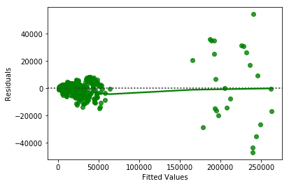

```python
ax=sns.residplot(np.exp(y_pred),((np.exp(y_pred))-y.TOTCOST), lowess=True, color="g")
ax.set(xlabel='Fitted Values', ylabel='Residuals')
plt.show()
```

*Heteroscedarcity is reduced to some extent*

```python
print("Mean squared error: %.2f"
      % mean_squared_error(y,np.exp(y_pred)))
# Explained variance score: 1 is perfect prediction
print('Variance score: %.2f' % r2_score(y, np.exp(y_pred)))
```

```
Mean squared error: 43152197.97
Variance score: 0.98
```

```python
#  K-fold cross validation
from sklearn.model_selection import ShuffleSplit
from sklearn.model_selection import cross_val_score

regr = LinearRegression()
cv = ShuffleSplit(n_splits=5, test_size=0.25, random_state=0)
scores = cross_val_score(regr, X[[ 'LNKWH','LNQ2','LNQ3','STOPS','LNSTAFF','LNNET','ELEC','TUNNEL','KWH']].values, y, scoring='neg_mean_squared_error', cv=cv)
print("regression model's mean squared errors of cross validation",-scores.mean())
```

```
regression model's mean squared errors of cross validation 36155603.4081
```

```python
from sklearn.linear_model import Ridge

#Ridge regression model
ridgeReg = Ridge(alpha=0.005, normalize=True)
ridgeReg.fit( X[[ 'LNKWH','LNQ2','LNQ3','STOPS','LNSTAFF','LNNET','ELEC','TUNNEL','KWH']],y)
y_ridge = ridgeReg.predict( X[[ 'LNKWH','LNQ2','LNQ3','STOPS','LNSTAFF','LNNET','ELEC','TUNNEL','KWH']])
```

```python
print("Mean squared error: %.2f"
      % mean_squared_error(y,(y_ridge)))
# Explained variance score: 1 is perfect prediction
print('Variance score: %.2f' % r2_score(y, (y_ridge)))
```

```
Mean squared error: 38226728.02
Variance score: 0.98
```

```python
n=0
scores=[0]*12
alpha=[1,.7,.5,.3,.1,.07,.05,.01,.007,.005,.001,.0005]
for i in alpha:
    ridgeReg = Ridge(alpha=i, normalize=True)
    cv = ShuffleSplit(n_splits=5, test_size=0.25, random_state=0)
    score = cross_val_score(ridgeReg, X[[ 'LNKWH','LNQ2','LNQ3','STOPS','LNSTAFF','LNNET','ELEC','TUNNEL','KWH']].values, y, scoring='neg_mean_squared_error', cv=cv)
    scores[n]=score.mean()
    print("mean of ridge regression model's mean squared errors of cross validation for alpha",i,"is",-score.mean())
    n+=1
```

```
mean of ridge regression model's mean squared errors of cross validation for alpha 1 is 286416914.072
mean of ridge regression model's mean squared errors of cross validation for alpha 0.7 is 227308857.491
mean of ridge regression model's mean squared errors of cross validation for alpha 0.5 is 178377302.417
mean of ridge regression model's mean squared errors of cross validation for alpha 0.3 is 119178513.708
mean of ridge regression model's mean squared errors of cross validation for alpha 0.1 is 54325638.7728
mean of ridge regression model's mean squared errors of cross validation for alpha 0.07 is 46295285.557
mean of ridge regression model's mean squared errors of cross validation for alpha 0.05 is 41803381.9534
mean of ridge regression model's mean squared errors of cross validation for alpha 0.01 is 36298325.6909
mean of ridge regression model's mean squared errors of cross validation for alpha 0.007 is 36172623.3459
mean of ridge regression model's mean squared errors of cross validation for alpha 0.005 is 36123704.8444
mean of ridge regression model's mean squared errors of cross validation for alpha 0.001 is 36128221.351
mean of ridge regression model's mean squared errors of cross validation for alpha 0.0005 is 36140374.2196
```

```python
from sklearn.linear_model import Lasso

#Lasso regression model
lassoReg = Lasso(alpha=0.1, normalize=True)
lassoReg.fit( X[[ 'LNKWH','LNQ2','LNQ3','STOPS','LNSTAFF','LNNET','ELEC','TUNNEL','KWH']],y)
y_lasso = lassoReg.predict( X[[ 'LNKWH','LNQ2','LNQ3','STOPS','LNSTAFF','LNNET','ELEC','TUNNEL','KWH']])
```

```python
print("Mean squared error: %.2f"
      % mean_squared_error(y,(y_lasso)))
# Explained variance score: 1 is perfect prediction
print('Variance score: %.2f' % r2_score(y, (y_lasso)))
```

```
Mean squared error: 38107566.24
Variance score: 0.98
```

```python
n=0
scores=[0]*14
alpha=[10,5,4,3,1,.7,.5,.3,.1,.07,.05,.01,.007,.005,.001,.0005]
for i in alpha:
    lassoReg = Lasso(alpha=i, normalize=True)
    cv = ShuffleSplit(n_splits=5, test_size=0.25, random_state=0)
    score = cross_val_score(lassoReg,  X[[ 'LNKWH','LNQ2','LNQ3','STOPS','LNSTAFF','LNNET','ELEC','TUNNEL','KWH']], y, scoring='neg_mean_squared_error', cv=cv)
    scores[n]=score.mean()
    print("mean of Lasso regression model's mean squared errors of cross validation for alpha",i,"is",-score.mean())
```

```
mean of Lasso regression model's mean squared errors of cross validation for alpha 10 is 36206268.8699
mean of Lasso regression model's mean squared errors of cross validation for alpha 5 is 36184120.1548
mean of Lasso regression model's mean squared errors of cross validation for alpha 4 is 36180176.775
mean of Lasso regression model's mean squared errors of cross validation for alpha 3 is 36190093.3429
mean of Lasso regression model's mean squared errors of cross validation for alpha 1 is 36175759.3379
mean of Lasso regression model's mean squared errors of cross validation for alpha 0.7 is 36152486.0021
mean of Lasso regression model's mean squared errors of cross validation for alpha 0.5 is 36144847.427
mean of Lasso regression model's mean squared errors of cross validation for alpha 0.3 is 36143985.6039
mean of Lasso regression model's mean squared errors of cross validation for alpha 0.1 is 36149789.1527
mean of Lasso regression model's mean squared errors of cross validation for alpha 0.07 is 36151233.374
mean of Lasso regression model's mean squared errors of cross validation for alpha 0.05 is 36151922.9361
mean of Lasso regression model's mean squared errors of cross validation for alpha 0.01 is 36154785.9287
mean of Lasso regression model's mean squared errors of cross validation for alpha 0.007 is 36155029.7204
mean of Lasso regression model's mean squared errors of cross validation for alpha 0.005 is 36155192.5921
mean of Lasso regression model's mean squared errors of cross validation for alpha 0.001 is 36155520.6166
mean of Lasso regression model's mean squared errors of cross validation for alpha 0.0005 is 36155562.0554
```

```python
from sklearn.linear_model import ElasticNet

#Lasso regression model
elasReg = ElasticNet(alpha=0.01,l1_ratio=0.5, normalize=True)
elasReg.fit( X[[ 'LNKWH','LNQ2','LNQ3','STOPS','LNSTAFF','LNNET','ELEC','TUNNEL','KWH']],y)
y_elas = elasReg.predict( X[[ 'LNKWH','LNQ2','LNQ3','STOPS','LNSTAFF','LNNET','ELEC','TUNNEL','KWH']])
```

```python
print("Mean squared error: %.2f"
      % mean_squared_error(y,(y_elas)))
# Explained variance score: 1 is perfect prediction
print('Variance score: %.2f' % r2_score(y, (y_elas)))
```

```
Mean squared error: 583385575.12
Variance score: 0.67
```

```python
n=0
scores=[0]*14
alpha=[10,5,4,3,1,.7,.5,.3,.1,.07,.05,.01,.007,.005,.001,.0005,0.0001,0.00007]
for i in alpha:
    elasReg = ElasticNet(alpha=i, normalize=True,l1_ratio=0.9)
    cv = ShuffleSplit(n_splits=5, test_size=0.25, random_state=0)
    score = cross_val_score(elasReg,  X[[ 'LNKWH','LNQ2','LNQ3','STOPS','LNSTAFF','LNNET','ELEC','TUNNEL','KWH']], y, scoring='neg_mean_squared_error', cv=cv)
    scores[n]=score.mean()
    print("mean of Lasso regression model's mean squared errors of cross validation for alpha",i,"is",-score.mean())
```

```
mean of Lasso regression model's mean squared errors of cross validation for alpha 10 is 1656474666.53
mean of Lasso regression model's mean squared errors of cross validation for alpha 5 is 1626337277.7
mean of Lasso regression model's mean squared errors of cross validation for alpha 4 is 1611679291.78
mean of Lasso regression model's mean squared errors of cross validation for alpha 3 is 1587834628.25
mean of Lasso regression model's mean squared errors of cross validation for alpha 1 is 1420293209.0
mean of Lasso regression model's mean squared errors of cross validation for alpha 0.7 is 1330765631.58
mean of Lasso regression model's mean squared errors of cross validation for alpha 0.5 is 1228650581.76
mean of Lasso regression model's mean squared errors of cross validation for alpha 0.3 is 1046555169.88
mean of Lasso regression model's mean squared errors of cross validation for alpha 0.1 is 642327072.034
mean of Lasso regression model's mean squared errors of cross validation for alpha 0.07 is 536372438.729
mean of Lasso regression model's mean squared errors of cross validation for alpha 0.05 is 451156103.454
mean of Lasso regression model's mean squared errors of cross validation for alpha 0.01 is 165442987.971
mean of Lasso regression model's mean squared errors of cross validation for alpha 0.007 is 124651961.324
mean of Lasso regression model's mean squared errors of cross validation for alpha 0.005 is 95029239.0366
mean of Lasso regression model's mean squared errors of cross validation for alpha 0.001 is 40881290.6039
mean of Lasso regression model's mean squared errors of cross validation for alpha 0.0005 is 37372572.6236
mean of Lasso regression model's mean squared errors of cross validation for alpha 0.0001 is 36116715.3957
mean of Lasso regression model's mean squared errors of cross validation for alpha 7e-05 is 36107064.9865
```

*Comparing the mean squared errors of Lasso, Ridge and regular regression, we find that lasso and ridge have lower mean squared error than simple linear regression*